# Which types of patients are most likely to survive breast cancer?

by Klaus BONOU SELEGBE

## Investigation Overview

In this investigation, I wanted to examine patient characteristics that could be used to predict their vital status: whether they are more likely to survive or not. Emphasis was placed on variables describing cancer advancement such as cancer cell grade (grade), cancer cell invasion level (n_stage), cancer stage (6th_stage), tumor size ( tumor_size). Relations with other variables such as the number of survival months (survival_months) and age will be briefly described.

## Dataset Overview

The data consists of information about 4024 breast cancer patients. It presents each patient's age, marital status, different stages of cancer advancement, tumor size, number of months he survived before recovering or dying, vital status and many more. The dataset can be found [here](https://www.kaggle.com/datasets/reihanenamdari/breast-cancer)

```python
# import all packages and set plots to be embedded inline
import numpy as np
import pandas as pd
import matplotlib.pyplot as plt
import seaborn as sb

%matplotlib inline

# suppress warnings from final output
import warnings
warnings.simplefilter("ignore")
```

```python
# load in the dataset into a pandas dataframe
breast_cancer_df = pd.read_csv('breast_cancer.csv')
```

### Preliminary Wrangling

```python
#Drop useless columns
breast_cancer_df.drop(['Regional Node Examined', 'Reginol Node Positive', 'T Stage '], axis = 1, inplace = True)

# Rename column
breast_cancer_df.rename(columns = lambda x : x.strip().lower().replace(" ", "_"), inplace = True)

# Replace " differentiated by ""
breast_cancer_df['differentiate'] = breast_cancer_df['differentiate'].apply(lambda x : x.replace(" differentiated", "").strip())

# Replace " anaplastic; Grade IV" by "4"
breast_cancer_df['grade'] = breast_cancer_df['grade'].apply(lambda x : x.replace(" anaplastic; Grade IV", "4").strip())
```

```python
'''
    Change the type of column to categorical one with ordered values or not

            Parameters:
                    cols_dict (dict): A dict with column name as key and their values as data
                    ordered (boolean): A boolean to indicate if values have to be oredered or not : set to True by default

            Returns:
                    void
'''
def change_type(cols_dict, ordered= True):
    if ordered :
        for col in cols_dict :
            breast_cancer_df[col] =  breast_cancer_df[col].astype(pd.api.types.CategoricalDtype(categories=cols_dict[col], ordered=True))
    else :
        for col in cols_dict :
            breast_cancer_df[col] =  breast_cancer_df[col].astype('category')
```

```python
# Categorical columns with their ordered values
ordinal_col = {'n_stage': ['N1','N2','N3'],
                '6th_stage': ['IIA', 'IIB', 'IIIA', 'IIIB', 'IIIC'],
                'differentiate': ['Undifferentiated','Poorly', 'Moderately', 'Well'],
                'grade': ['1', '2', '3', '4']}

# Nominal columns with their values
nominal_col = {'race': ['White','Black','Other'],
                'marital_status': ['Single ', 'Married', 'Divorced', 'Widowed', 'Separated'],
                'a_stage': ['Regional', 'Distant'],
                'estrogen_status': ['Positive', 'Negative'],
                'progesterone_status': ['Positive', 'Negative'],
                'status': ['Alive', 'Dead']}

# The two lines below change the type of categorical columns to the rght types for both nominal and ordinal variables
change_type(ordinal_col)
change_type(nominal_col, ordered= False)
```

### Distribution of Patient's status : The proportions

There is more patients alive than dead. Around 85% of patients of this dataset are alive whereas around 15% are dead.

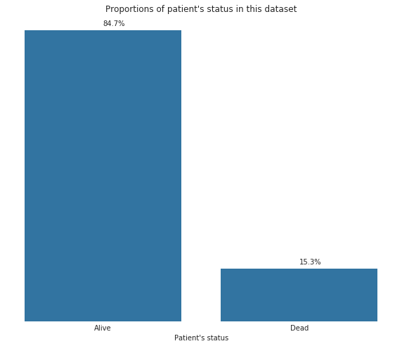

```python
fig, axes = plt.subplots(figsize=[10,8])
axes.get_yaxis().set_visible(False)

base_color = sb.color_palette()[0]

# Value counts for status variable
status_count = breast_cancer_df['status'].value_counts()

# Total number of values
sum_count = breast_cancer_df.shape[0]

#Plotting
sb.countplot(data = breast_cancer_df, x = 'status', color = base_color);

# This loop add the corresponding percent above each bar
for i in range(status_count.shape[0]):
    count = status_count[i]
    percent_str = '{:.1f}%'.format(100*count/sum_count)
    plt.text(i, count+80, percent_str, va='center')

# Enhance the visualization
sb.set_style("whitegrid", {'axes.grid' : False, 'grid.linestyle': ''})
axes.spines.clear()

axes.set_title("Proportions of patient's status in this dataset");
axes.set_xlabel("Patient's status");
```

## Patient's status vs their tumor size, age and survival months

- Alive patients are approximately 32 years old to 69, their tumor_size is among the smallest and they survive during a long time at least around 50 months
- Dead patients are of all ages, but a large number of dead patients are betweeen 60 and 70. Their tumor_size is among the smallest too but not as Alive patients...almost the same range, and they survive not necessarly a long time before dying.

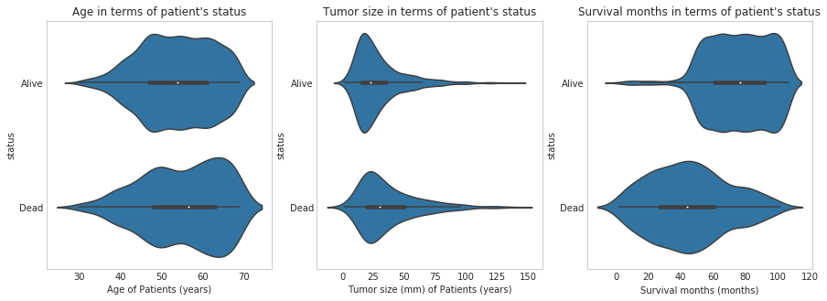

```python
fig, axes = plt.subplots(ncols=3, figsize=[15,5])
#axes.get_yaxis().set_visible(False)

sb.violinplot(data=breast_cancer_df, x='age', y='status', ax=axes[0], color=base_color)
sb.violinplot(data=breast_cancer_df, x='tumor_size', y='status', ax=axes[1], color=base_color)
sb.violinplot(data=breast_cancer_df, x='survival_months', y='status', ax=axes[2], color=base_color)

axes[0].set_title("Age in terms of patient's status")
axes[0].set_xlabel('Age of Patients (years)');
axes[1].set_title("Tumor size in terms of patient's status")
axes[1].set_xlabel('Tumor size (mm) of Patients (years)');
axes[2].set_title("Survival months in terms of patient's status")
axes[2].set_xlabel('Survival months (months)');
```

## Patient's status vs both tumor size and survival months

Confirmation of the previous observations :

Alive patients in this dataset have mostly, a relative small tumor_size , and survive many months around over 50 or 60 Patients with tumor size great than 70mm are less likely to survive seing the the distribution of Dead patients in this dataset (15% of Dead patients) and the number of dead patients with tumor size great than 70mm.

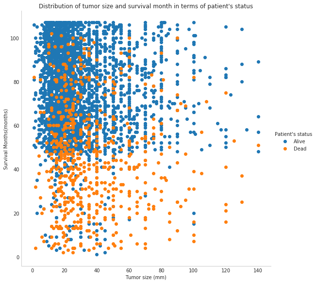

```python
g = sb.FacetGrid(data=breast_cancer_df, hue='status', size=8)
g.map(plt.scatter, 'tumor_size', 'survival_months');

g.set(title= "Distribution of tumor size and survival month in terms of patient's status", xlabel="Tumor size (mm)", ylabel="Survival Months(months)")
g.add_legend(title="Patient's status");
```

## Influence of cancer stage on the patient's status

- Proportionally patients with advanced stage (N3), (it means with a high degree of invasion for carcinogenic cells) are less likely to survive than if their cancer was at a lower stage(N1 or N2).
- Patients with advanced stage for 6th_stage(IIIC, IIIB, IIIA), are less likely to survive than if their cancer's 6th stage was at a lower stage(IIA or IIB).
- Proportionally, patients die most when the carcinogenic cells is at advanced grade (grade 3 and 4)
- Concerning marital status, separated, widowed, single and divorced patients respectively are less likely to survive than married ones.

**Patients with advanced stage are less likely to survive than if their cancer was at a lower stage.**

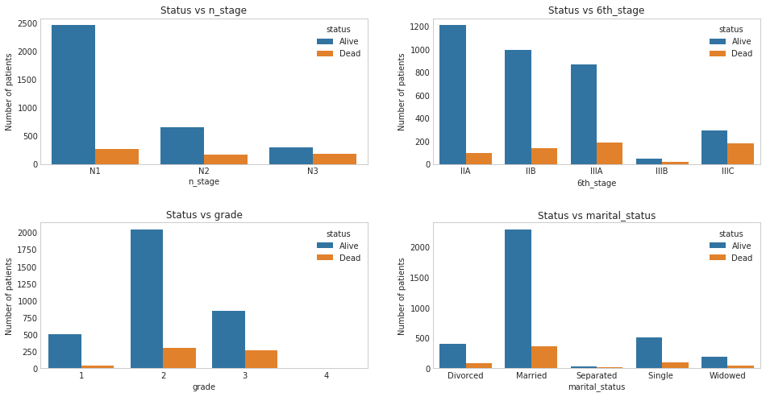

```python
'''
    Draw grouped grouped bar for precised variables

            Parameters:
                    axis_row (int): Number of rows of the axis in which we have to draw the plot
                    axis_col (int): Number of cols of the axis in which we have to draw the plot

                    x_vars (list): List of columns for which we have to draw grouped bar

            Returns:
                    grouped bar
'''

def draw_grouped_bar(axis_row, axis_col, x_vars):
    cpt = 0
    for i in range(axis_row):
        for j in range(axis_col):
            sb.countplot(data = breast_cancer_df, x=x_vars[cpt], hue='status', ax=axes[i,j]);
            axes[i,j].set_title('Status vs '+x_vars[cpt])
            axes[i,j].set_ylabel('Number of patients');
            cpt +=1

fig, axes = plt.subplots(2,2, figsize=[16,8])
plt.subplots_adjust(wspace=0.2, hspace=0.4)

draw_grouped_bar(2, 2, ['n_stage', '6th_stage', 'grade', 'marital_status'])
```

## Influence of cancer stage (6th stage), tumor size on patient's status

Let's try to understand more 6th stage values.

### Staging System for Breast Cancer

[output not shown]

*Note :*  
*T1 <=> [1mm - 20mm]*  
*T2 <=> [2mm - 50mm]*  
*T3 <=> More than 50mm*  
*T4 <=> Any size with direct extension to chest wall and/or to skin*

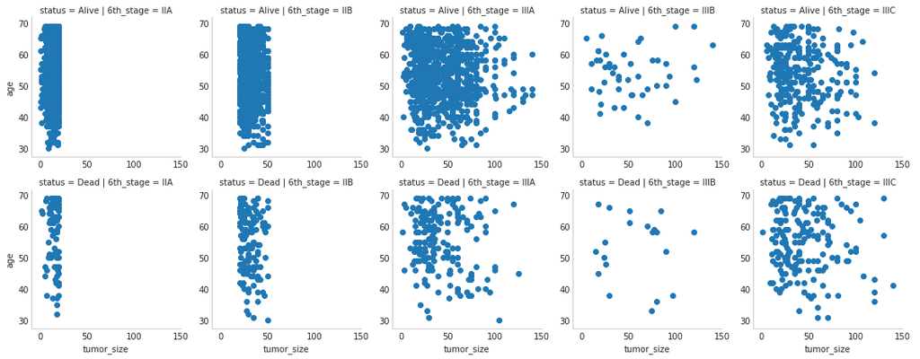

```python
'''
            Draw scatter plots between 4 variables (2 categorical and 2 numerical)

            Parameters:
                    cat_var (str) : column which represent the second categorical variable

            Returns:
                    scatter plot
'''

def draw_multi_scatter_plot(cat_var):
    g = sb.FacetGrid(data=breast_cancer_df, row='status', col=cat_var, size=3)
    g.map(plt.scatter, 'tumor_size', 'age');
    g.add_legend();

draw_multi_scatter_plot('6th_stage')
```

## Influence of agressivness of the carcinogenic cells (grade), tumor size on patient's status

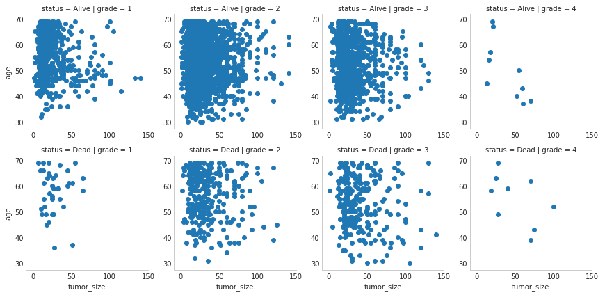

```python
draw_multi_scatter_plot('grade')
```

# General Conclusion

## Patients with small tumor size , a lower grade(the agressivness of the carcinogenic cells) and a lower cancer stage are more likely to survive.

### Generate Slideshow

Once you're ready to generate your slideshow, use the `jupyter nbconvert` command to generate the HTML slide show.

```python
# Use this command if you are running this file in local
!jupyter nbconvert 'Part_II_Breast_Cancer_Slides.ipynb' --to slides --post serve --no-input --no-prompt
```

[output not shown]

### Submission

If you are using classroom workspace, you can choose from the following two ways of submission:

1. **Submit from the workspace**. Make sure you have removed the example project from the /home/workspace directory. You must submit the following files:
   - Part_I_notebook.ipynb
   - Part_I_notebook.html or pdf
   - Part_II_notebook.ipynb
   - Part_I_slides.html
   - README.md
   - dataset (optional)
1. **Submit a zip file on the last page of this project lesson**. In this case, open the Jupyter terminal and run the command below to generate a ZIP file.

   ```
   zip -r my_project.zip .
   ```

   The command abobve will ZIP every file present in your /home/workspace directory. Next, you can download the zip to your local, and follow the instructions on the last page of this project lesson.